# Prosper Loans Data Exploration through Visualizations

## by Christopher Toromo

## Investigation Overview

The objective of the project is to conduct an exploratory data analysis on a Prosper Loan dataset. This is through the use of Python data science and data visualization libraries to explore the dataset’s variables and understand the data’s structure, oddities, patterns, and relationships.

## Dataset Overview

This data set contains 113,937 loans with 81 variables on each loan, including loan amount, borrower rate (or interest rate), current loan status, borrower income, and many others.

The data set can be found [here](https://s3.amazonaws.com/udacity-hosted-downloads/ud651/prosperLoanData.csv) and the variable descriptions can be found [here](https://docs.google.com/spreadsheets/u/0/d/1gDyi_L4UvIrLTEC6Wri5nbaMmkGmLQBk-Yx3z0XDEtI/edit?usp=sharing).

## Bar charts for the IncomeRange variable and the LoanStatus variable

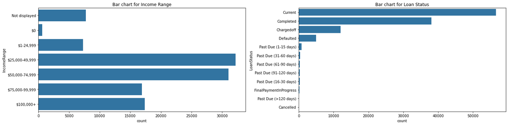

**From the above observation, we can easily tell that people on mid-range salary levels are the ones requesting most loans and that the most loans are still active.**

# Histogram for the EstimatedLoss variable and EstimatedReturn variable and Average Credit Score

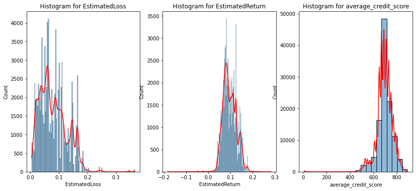

**From the above, the distribution of the Estimated loss is skewed to the right, while the Estimated return variable is slightly symmetrical. Also most loans are requested by people with a credit score of 700. Also the credit score rating is skewed to the left.**

# Scatter plots for the BorrowerAPR and average_credit_score vs BorrowerRate and variables

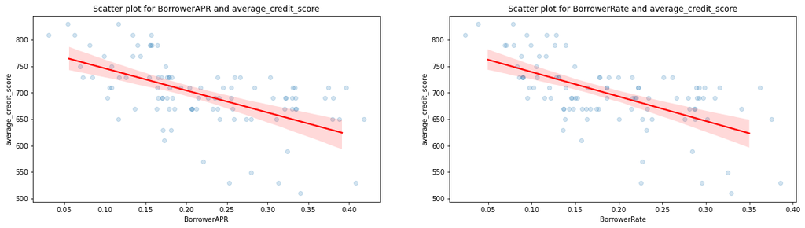

**From the above we can tell from the above that the higher the credit score of a person, the lower the interest rate on the loan.**